# TS_PPLE_2023Spring_Midterm

```r
library(fpp3)
```

# 0. Import data

Run the code below. A pop-up window will appear (look for it). Select the file “Spain_Arrivals_Monthly.csv”, placed in the ZZ_Datasets folder

```r
sp_arrivals <- readr::read_delim(file.choose(), delim = ",") %>%
            mutate(year = substr(period, 1, 4),
                   month = substr(period, 6, 8),
                   ym = make_yearmonth(year = year, month = month),
                   value = as.numeric(gsub(".", "", value, fixed=TRUE))
                   ) %>%
            select(ym, value) %>%
            as_tsibble()
```

```r
sp_arrivals
```

```
# A tsibble: 83 x 2 [1M]
         ym   value
      <mth>   <dbl>
 1 2015 Oct 6432341
 2 2015 Nov 3754802
 3 2015 Dec 3512914
 4 2016 Jan 3526537
 5 2016 Feb 3678726
 6 2016 Mar 4627206
 7 2016 Apr 6086327
 8 2016 May 7111154
 9 2016 Jun 7552758
10 2016 Jul 9545792
# ℹ 73 more rows
```

# 1. Basic plots

## 1.1 Create a time-plot of the series, adjusting the time grid so that it signals the beginning of every year

```
Plot variable not specified, automatically selected `.vars = value`
```

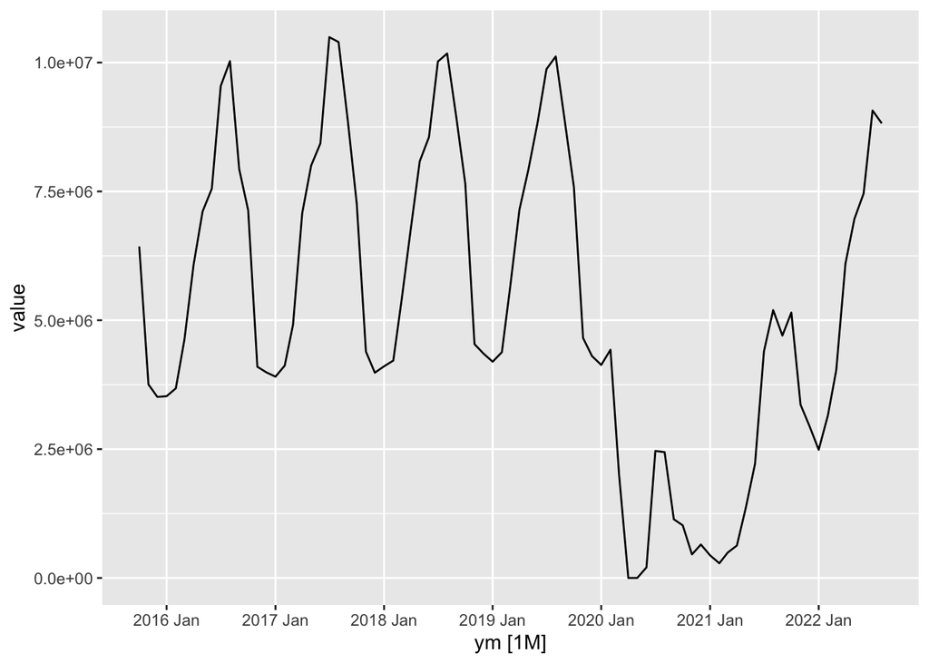

```r
sp_arrivals %>%

  autoplot() +

  scale_x_yearmonth(
    breaks = "1 years",
    minor_breaks = "1 year"
  )
```

## 1.2 Looking at the timeplot prior to 2020, what is the seasonal period you would expect? (max. 30 words)

There is a clearly repeating pattern every year that indicates yearle seasonality. With monthly data, the seasonal period wold be m = 12.

## 1.3 Looking at the timeplot, judge briefly the strength of the seasonal vs the trend component:

Prior to 2020 the trend is very mild. The seasonal component has a greater variance and dominates. After COVID strikes in 2020, this regular structure is broken and the trend increases in importance.

# 2. TS Decomposition

## 2.1 Perform an STL decomposition with default arguments. Depict the decomposition.

Store the resulting components in a variable called `STL_defaults`. Then depict the resulting decomposition.

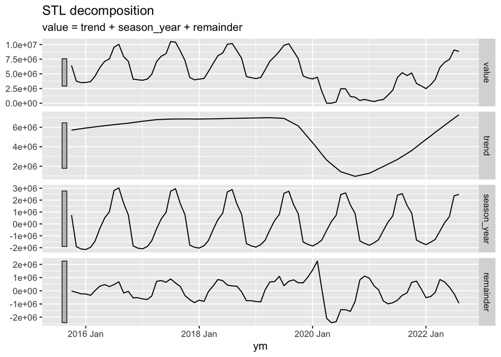

```r
STL_defaults <-
  sp_arrivals %>%
    model(
      stl = STL(value)
    ) %>%
  components()

STL_defaults %>% autoplot()
```

## 2.1.1 If you can, adjust the parameters of the STL decomposition to improve it. Depict the resulting decomposition.

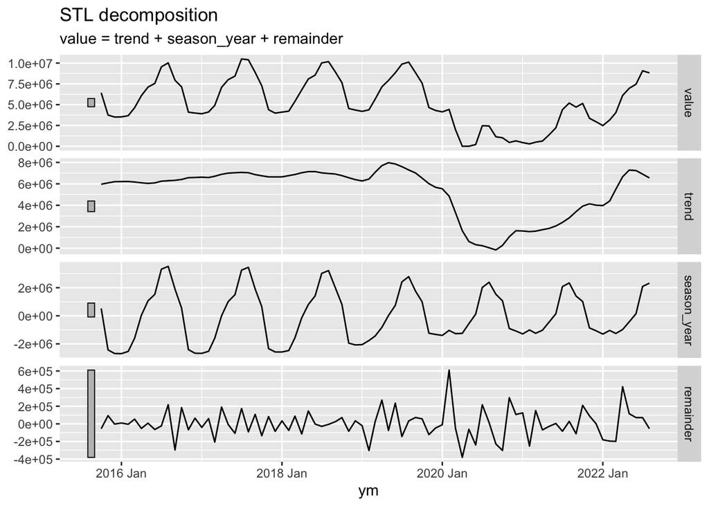

```r
STL_adjust <-
  sp_arrivals %>%
    model(
      stl = STL(value ~ trend(window=5) + season(window=5))
    ) %>%
  components()

STL_adjust %>% autoplot()
```

## 2.1.2 What are the most important limitations of the STL decomposition in general?

See associated theory session.

## 2.1.3 Check, in fact, the decomposition is indeed a breakdown of the time series.

```r
all.equal(round(sp_arrivals$value, 3), (STL_adjust$trend + STL_adjust$season_year + STL_adjust$remainder))
```

```
[1] TRUE
```

## 2.2 Perform a classical decomposition. Store the resulting components in a tsibble called `dcmp_classic`

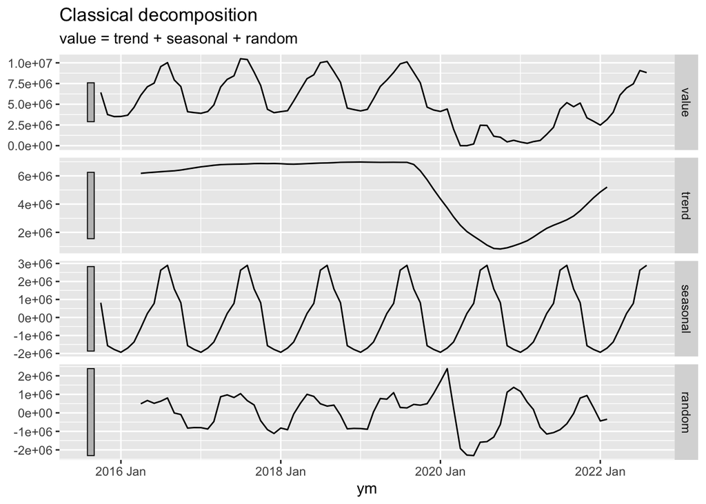

```r
dcmp_classic <-
  sp_arrivals %>%
  model(
    classical = classical_decomposition(value)
  ) %>%
  components()

dcmp_classic %>% autoplot()
```

## 2.3 Compare the STL and Classical decompositions in terms of:

1. Variance of their components (assess graphically)
- STL decomposition (adjusted)
  - Variance of remainder much smaller than both the trend and seasonal components.
- Classical decomposition
  - Variancer of the remainder very similar to variance of seasonal and trend
- Conclusion: STL decomposition (adjusted) is better
2. Autocorrelation of the remainder / irregular component

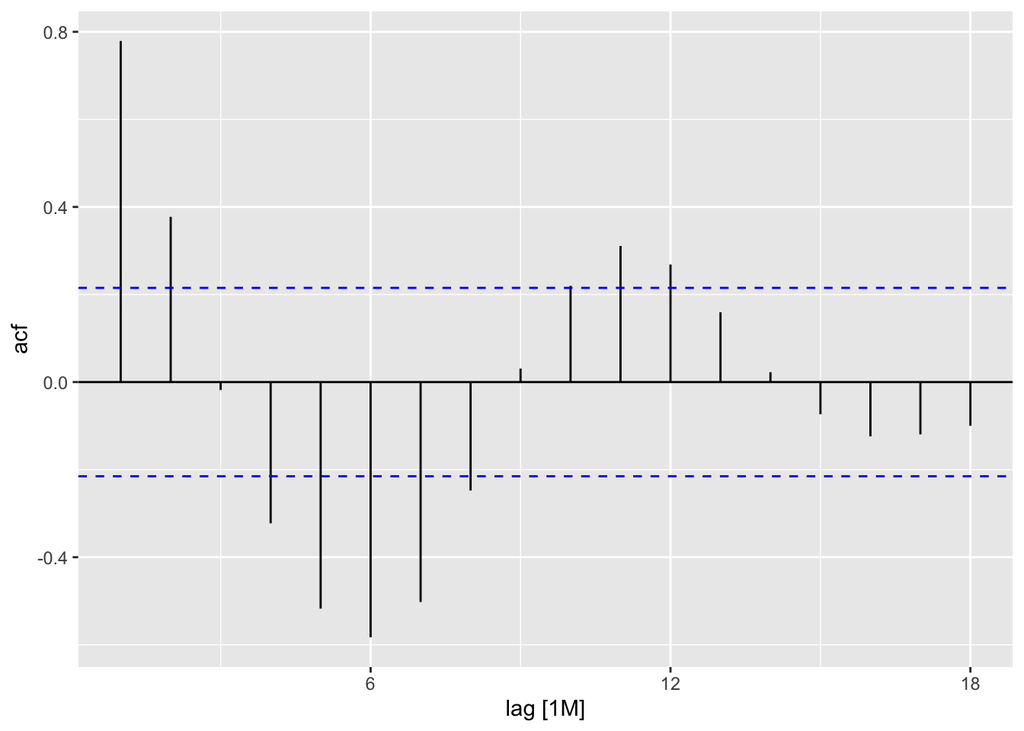

```r
dcmp_classic %>%
  ACF(random) %>%
  autoplot()
```

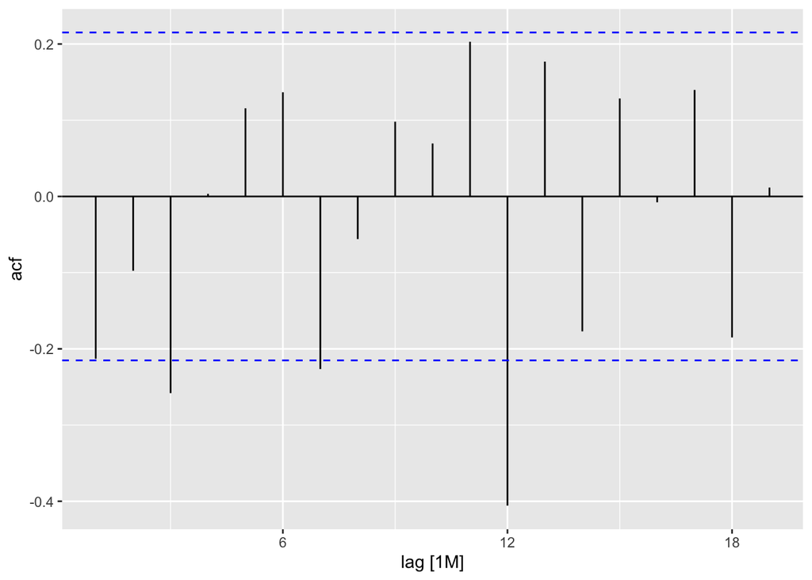

```r
STL_adjust %>%
  ACF(remainder) %>%
  autoplot()
```

Clearly the remainder of the adjusted STL decomposition is better, because it is more white-noise like.

# 3. Benchmark modes

## 3.1 Filter a subset of the data so that you retain only data up to January 2020. Store it in a new variable called `sp_arrivals_jan2020`

```r
sp_arrivals_jan2020 <-
  sp_arrivals %>%
  filter(ym < yearmonth("2020 Jan"))
```

## 3.2 Consider two tsibbles: the original `sp_arrivals` and the reduced `sp_arivals_jan2020`. Then fit the following forecasting models to each of these tsibbles seaparately. Store the in `fit` and `fit_jan2020`

1. Seasonal Naive model
2. SES model
3. Drift model
4. `decomposition_model()` using STL for the decomposition (decomposition you used in section 2) + SES for seasonally adjusted component + seasonal naive for seasoanl component.
5. `decomposition_model()` using STL for the decomposition (decomposition you used in section 2) + drift() for seasonally adjusted component + seasonal naive for seasoanl component.

```r
fit <-
  sp_arrivals %>%
  model(
    snaive = SNAIVE(value),
    ses = ETS(value ~ error("A") + trend ("N") + season("N")),
    drift = RW(value ~ drift()),
    dcmp_ses = decomposition_model(
                  STL(value ~ trend(window=5) + season(window=5)),
                  ETS(season_adjust ~ error("A") + trend ("N") + season("N")),
                  SNAIVE(season_year)
                ),
    dcmp_drift = decomposition_model(
                  STL(value ~ trend(window=5) + season(window=5)),
                  RW(season_adjust ~ drift()),
                  SNAIVE(season_year)
                )
  )

fit_jan2020 <-
  sp_arrivals_jan2020 %>%
  model(
    snaive = SNAIVE(value),
    ses = ETS(value ~ error("A") + trend ("N") + season("N")),
    drift = RW(value ~ drift()),
    dcmp_ses = decomposition_model(
                  STL(value ~ trend(window=5) + season(window=5)),
                  ETS(season_adjust ~ error("A") + trend ("N") + season("N")),
                  SNAIVE(season_year)
                ),
    dcmp_drift = decomposition_model(
                  STL(value ~ trend(window=5) + season(window=5)),
                  RW(season_adjust ~ drift()),
                  SNAIVE(season_year)
                )
  )
```

## 3.3 Produce forecasts of up to 1 year ahead with all the models. Store them in two variables called `fc_arrivals` and `fc_arrivals_jan2020`.

```r
fc_arrivals <- fit %>% forecast(h = 12)

fc_arrivals_jan2020 <-  fit_jan2020 %>% forecast(h=12)
```

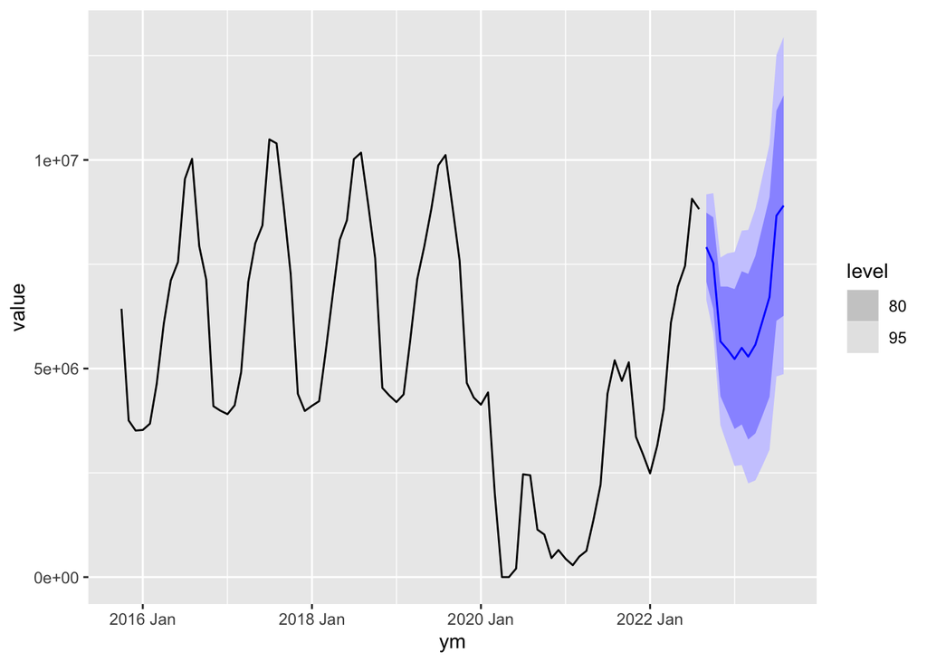

```r
fc_arrivals %>%
  filter(.model == "dcmp_drift") %>%
  autoplot(sp_arrivals)
```

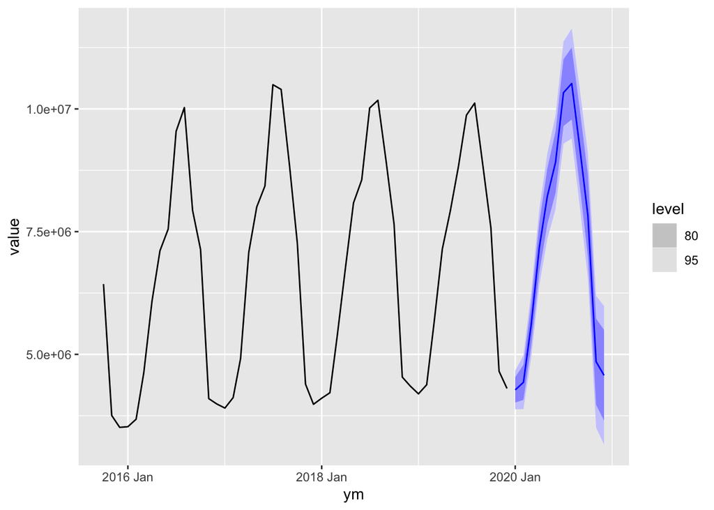

```r
fc_arrivals_jan2020 %>%
  filter(.model == "dcmp_drift") %>%
  autoplot(sp_arrivals_jan2020)
```

# 4. Assess the residuals of `decomposition_model()` using SES for the seasonally adjusted component that has been fitted to the totality of the time series. For the autocorrelation, be sure to include use of the Ljung-Box or Box-Pierce statistics.

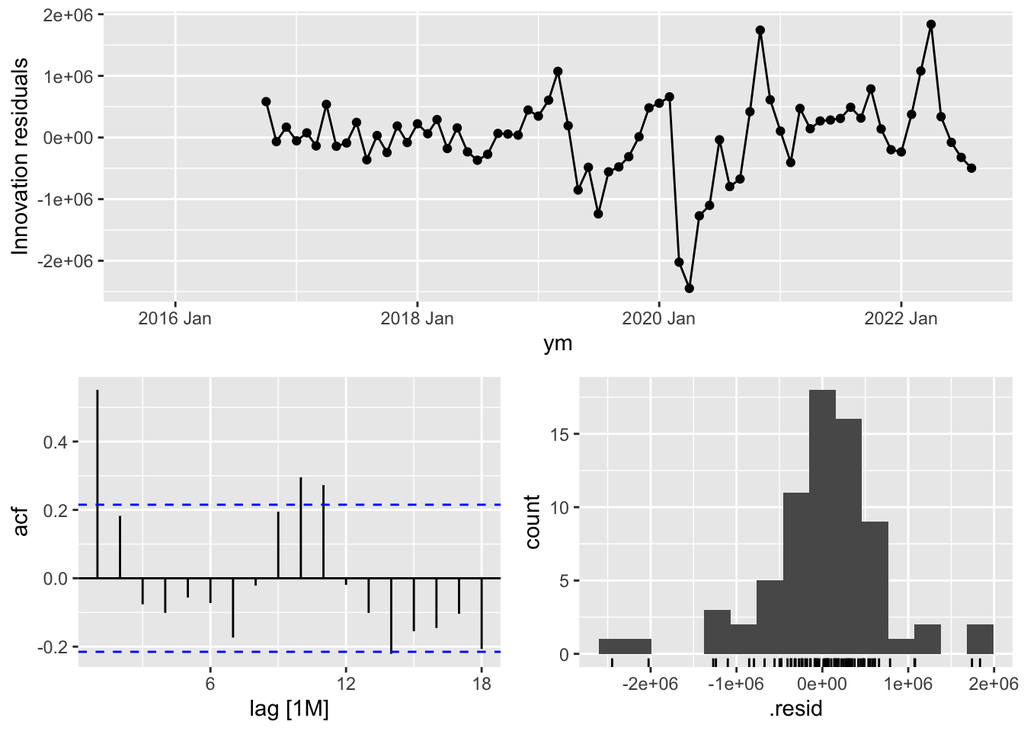

```r
fit %>%
  select(dcmp_ses) %>%
  gg_tsresiduals()
```

```r
# ASSESMENT AND OTHER NECESSARY GRAPHS LEFT TO YOU
```